# Kari Palmier, CSC 578 Section 710, Final Project

Import all necessary packages.

```python
import numpy as np
import pandas as pd
import keras
from keras.models import Sequential
from keras.layers import LSTM, Dense, Dropout
import matplotlib.pyplot as plt
from datetime import datetime
from sklearn.preprocessing import MinMaxScaler
from sklearn.metrics import mean_squared_error, mean_absolute_error
import json
```

# Import and Verify Data

Read data into a pandas dataframe.

```python
climate_df = pd.read_csv("C:\\DePaulCoursework\\Fall 2018 CSC 578\\Assignments\\Final Project\\climate_hour.csv", delimiter=",", index_col=None, header=0)
```

Print out information on the dataframe to determine any modifications that may be necessary. Note that the Date Time column was read in as an object. This should be a date/time object.

```python
print(climate_df.shape)
print(climate_df.dtypes)
print(climate_df.head(3))
```

```
(70037, 15)
Date Time           object
p (mbar)           float64
T (degC)           float64
Tpot (K)           float64
Tdew (degC)        float64
rh (%)             float64
VPmax (mbar)       float64
VPact (mbar)       float64
VPdef (mbar)       float64
sh (g/kg)          float64
H2OC (mmol/mol)    float64
rho (g/m**3)       float64
wv (m/s)           float64
max. wv (m/s)      float64
wd (deg)           float64
dtype: object
             Date Time  p (mbar)  T (degC)  Tpot (K)  Tdew (degC)  rh (%)  \
0  01.01.2009 01:00:00    996.50     -8.05    265.38        -8.78    94.4
1  01.01.2009 02:00:00    996.62     -8.88    264.54        -9.77    93.2
2  01.01.2009 03:00:00    996.84     -8.81    264.59        -9.66    93.5

   VPmax (mbar)  VPact (mbar)  VPdef (mbar)  sh (g/kg)  H2OC (mmol/mol)  \
0          3.33          3.14          0.19       1.96             3.15
1          3.12          2.90          0.21       1.81             2.91
2          3.13          2.93          0.20       1.83             2.94

   rho (g/m**3)  wv (m/s)  max. wv (m/s)  wd (deg)
0       1307.86      0.21           0.63     192.7
1       1312.25      0.25           0.63     190.3
2       1312.18      0.18           0.63     167.2
```

Convert the Date Time column to a python date/time object. This is necessary so the column can be interpretted properly by python (data can be sorted and plotted by date for example).

```python
climate_df['Date Time'] = pd.to_datetime(climate_df['Date Time'], format='%d.%m.%Y %H:%M:%S')
```

Change the column names from their defaults to ones that are formatted as proper variables. The original names contained special characters and spaces (* for example). These are not appropriate to be used in variable names.

```python
climate_df.columns = ['date_time', 'atm_pressure', 'temperature', 'pot_temp_K', 'dew_temp_C', 'relative_humidity',
                      'sat_water_vap_pressure', 'act_water_vap_pressure', 'water_vap_pressure_deficit',
                      'specific_humidity', 'water_vap_concentration', 'air_density', 'wind_velocity',
                      'max_wind_velocity', 'wind_dir']
```

Print out newly converted dataframe to verify changes were made properly.

```python
print(climate_df.dtypes)
print(climate_df.head(3))
```

```
date_time                     datetime64[ns]
atm_pressure                         float64
temperature                          float64
pot_temp_K                           float64
dew_temp_C                           float64
relative_humidity                    float64
sat_water_vap_pressure               float64
act_water_vap_pressure               float64
water_vap_pressure_deficit           float64
specific_humidity                    float64
water_vap_concentration              float64
air_density                          float64
wind_velocity                        float64
max_wind_velocity                    float64
wind_dir                             float64
dtype: object
            date_time  atm_pressure  temperature  pot_temp_K  dew_temp_C  \
0 2009-01-01 01:00:00        996.50        -8.05      265.38       -8.78
1 2009-01-01 02:00:00        996.62        -8.88      264.54       -9.77
2 2009-01-01 03:00:00        996.84        -8.81      264.59       -9.66

   relative_humidity  sat_water_vap_pressure  act_water_vap_pressure  \
0               94.4                    3.33                    3.14
1               93.2                    3.12                    2.90
2               93.5                    3.13                    2.93

   water_vap_pressure_deficit  specific_humidity  water_vap_concentration  \
0                        0.19               1.96                     3.15
1                        0.21               1.81                     2.91
2                        0.20               1.83                     2.94

   air_density  wind_velocity  max_wind_velocity  wind_dir
0      1307.86           0.21               0.63     192.7
1      1312.25           0.25               0.63     190.3
2      1312.18           0.18               0.63     167.2
```

Check if there are any entries that are null in the dataframe. There are none present, so no dataset modification is required.

```python
climate_df.isnull().sum().sum()
```

```
0
```

Check to see if there are any duplicated entries in the dataframe. There are none present.

```python
dup_ndx = climate_df.index.duplicated(keep = False)
sum(dup_ndx)
```

```
0
```

Plot the temperature (C) versus time to examine any characteristics. The plot shows that the data is sequential (no time sorting required). The plot also shows distinct seasonality, with temperatures higher in the summer and lower in the winter.

```
Text(0.5,1,'Temperature (C) Over Time')
```

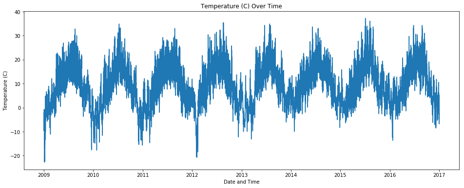

```python
plt.figure(figsize=(16, 6))
plt.plot(climate_df['date_time'], climate_df['temperature'])
plt.xlabel('Date and Time')
plt.ylabel('Temperature (C)')
plt.title('Temperature (C) Over Time')
```

Set the index of the dataframe to the date/time column since each row has a date/time entry. Print the dataframe to verify the change was made correctly.

```python
climate_df.set_index(['date_time'], inplace = True)
print(climate_df.head(3))
```

```
                     atm_pressure  temperature  pot_temp_K  dew_temp_C  \
date_time
2009-01-01 01:00:00        996.50        -8.05      265.38       -8.78
2009-01-01 02:00:00        996.62        -8.88      264.54       -9.77
2009-01-01 03:00:00        996.84        -8.81      264.59       -9.66

                     relative_humidity  sat_water_vap_pressure  \
date_time
2009-01-01 01:00:00               94.4                    3.33
2009-01-01 02:00:00               93.2                    3.12
2009-01-01 03:00:00               93.5                    3.13

                     act_water_vap_pressure  water_vap_pressure_deficit  \
date_time
2009-01-01 01:00:00                    3.14                        0.19
2009-01-01 02:00:00                    2.90                        0.21
2009-01-01 03:00:00                    2.93                        0.20

                     specific_humidity  water_vap_concentration  air_density  \
date_time
2009-01-01 01:00:00               1.96                     3.15      1307.86
2009-01-01 02:00:00               1.81                     2.91      1312.25
2009-01-01 03:00:00               1.83                     2.94      1312.18

                     wind_velocity  max_wind_velocity  wind_dir
date_time
2009-01-01 01:00:00           0.21               0.63     192.7
2009-01-01 02:00:00           0.25               0.63     190.3
2009-01-01 03:00:00           0.18               0.63     167.2
```

Plot all columns out over number of points to see each variable's behavior over time. There are distinct seasonality behaviors to all variables except atmospheric pressure, wind velocity, max wind velocity, and wind direction. Relative humidity also does seem to have some seasonality to its minimum values. Temperature, potential temperature, dew temperature, saturated water vapor pressure, actual water vapor pressure, vapor water pressure deficit, specific humidity, water vapor concentration, and air density all have strong seasonality behavior. All are higher during the summer months and lower during the winter months.

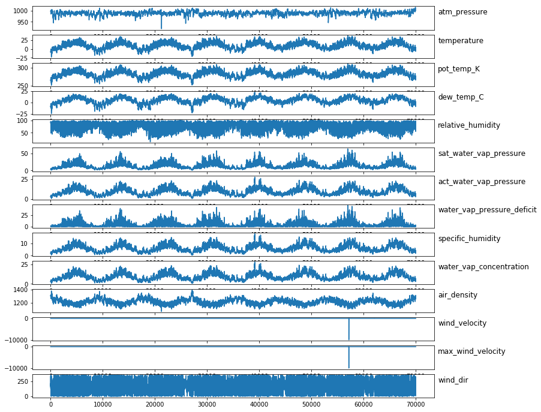

```python
values = climate_df.values
groups = range(0, climate_df.shape[1])

# plot each column
i = 1
plt.figure(figsize=(12, 12))
for group in groups:
    plt.subplot(len(groups), 1, i)
    plt.plot(values[:, group])
    plt.title(climate_df.columns[group], y = 0.5, x = 1.01, loc = 'left')
    i += 1
plt.show()
```

```python
climate_corr = climate_df.corr(method = "pearson")
print(climate_corr)
```

```
                            atm_pressure  temperature  pot_temp_K  dew_temp_C  \
atm_pressure                    1.000000    -0.045327   -0.124718   -0.066707
temperature                    -0.045327     1.000000    0.996823    0.895986
pot_temp_K                     -0.124718     0.996823    1.000000    0.895185
dew_temp_C                     -0.066707     0.895986    0.895185    1.000000
relative_humidity              -0.018423    -0.571708   -0.566415   -0.156375
sat_water_vap_pressure         -0.031463     0.951090    0.947264    0.799511
act_water_vap_pressure         -0.054373     0.867999    0.866530    0.968323
water_vap_pressure_deficit     -0.003241     0.761453    0.756659    0.435892
specific_humidity              -0.069758     0.867077    0.866855    0.967578
water_vap_concentration        -0.069796     0.867501    0.867278    0.968024
air_density                     0.307737    -0.963371   -0.981327   -0.885434
wind_velocity                  -0.005683    -0.004982   -0.004489   -0.008618
max_wind_velocity              -0.007256    -0.003957   -0.003344   -0.009747
wind_dir                       -0.063917     0.040067    0.044989    0.050842

                            relative_humidity  sat_water_vap_pressure  \
atm_pressure                        -0.018423               -0.031463
temperature                         -0.571708                0.951090
pot_temp_K                          -0.566415                0.947264
dew_temp_C                          -0.156375                0.799511
relative_humidity                    1.000000               -0.615276
sat_water_vap_pressure              -0.615276                1.000000
act_water_vap_pressure              -0.151410                0.825178
water_vap_pressure_deficit          -0.843500                0.875443
specific_humidity                   -0.150750                0.824768
water_vap_concentration             -0.150883                0.824803
air_density                          0.513574               -0.901467
wind_velocity                       -0.004185               -0.004417
max_wind_velocity                   -0.008599               -0.003223
wind_dir                            -0.017539               -0.009140

                            act_water_vap_pressure  \
atm_pressure                             -0.054373
temperature                               0.867999
pot_temp_K                                0.866530
dew_temp_C                                0.968323
relative_humidity                        -0.151410
sat_water_vap_pressure                    0.825178
act_water_vap_pressure                    1.000000
```

[output cut: 40 more lines]

```
                            wind_velocity  max_wind_velocity  wind_dir
atm_pressure                    -0.005683          -0.007256 -0.063917
temperature                     -0.004982          -0.003957  0.040067
pot_temp_K                      -0.004489          -0.003344  0.044989
dew_temp_C                      -0.008618          -0.009747  0.050842
relative_humidity               -0.004185          -0.008599 -0.017539
sat_water_vap_pressure          -0.004417          -0.003223 -0.009140
act_water_vap_pressure          -0.009420          -0.010935  0.019511
water_vap_pressure_deficit       0.001078           0.004262 -0.031146
specific_humidity               -0.009301          -0.010790  0.020501
water_vap_concentration         -0.009304          -0.010791  0.020736
air_density                      0.003487           0.002233 -0.059551
wind_velocity                    1.000000           0.865945 -0.015321
max_wind_velocity                0.865945           1.000000 -0.014704
wind_dir                        -0.015321          -0.014704  1.000000
```

# Normalize Data

Create a list of the variable names to be used in the normalization and RNN input data creation.

```python
var_names = list(climate_df.columns)
print(var_names)
```

```
['atm_pressure', 'temperature', 'pot_temp_K', 'dew_temp_C', 'relative_humidity', 'sat_water_vap_pressure', 'act_water_vap_pressure', 'water_vap_pressure_deficit', 'specific_humidity', 'water_vap_concentration', 'air_density', 'wind_velocity', 'max_wind_velocity', 'wind_dir']
```

Create a list of the date/time values to be used as the index of a dataframe of the normalized data.

```python
date_time = pd.Series(climate_df.index.values)
date_time.head(3)
```

```
0   2009-01-01 01:00:00
1   2009-01-01 02:00:00
2   2009-01-01 03:00:00
dtype: datetime64[ns]
```

Normalize all columns of the data to be between 0 and 1. This is done to ensure that all of the variable values are in the same range. Each variable of the original data had very different value ranges. If the data is not normalized, the variables with larger values could have more effect on the modeling algorithms than those with smaller values.

```python
min_max_scaler = MinMaxScaler(feature_range=(0, 1)).fit(climate_df)
climate_norm_np = min_max_scaler.transform(climate_df)
```

Create a dataframe of the normalized data. Set the column names and index to those of the original un-normalized dataframe.

```python
climate_norm_df = pd.DataFrame(climate_norm_np, columns = var_names, index = date_time)
climate_norm_df.head(3)
```

|  | atm_pressure | temperature | pot_temp_K | dew_temp_C | relative_humidity | sat_water_vap_pressure | act_water_vap_pressure | water_vap_pressure_deficit | specific_humidity | water_vap_concentration | air_density | wind_velocity | max_wind_velocity | wind_dir |
| --- | --- | --- | --- | --- | --- | --- | --- | --- | --- | --- | --- | --- | --- | --- |
| 2009-01-01 01:00:00 | 0.805868 | 0.245003 | 0.240722 | 0.335568 | 0.935588 | 0.037580 | 0.085567 | 0.004130 | 0.083190 | 0.084416 | 0.740479 | 0.998764 | 0.998034 | 0.535278 |
| 2009-01-01 02:00:00 | 0.807108 | 0.231179 | 0.226806 | 0.314830 | 0.921785 | 0.034236 | 0.076754 | 0.004564 | 0.074584 | 0.075758 | 0.753930 | 0.998768 | 0.998034 | 0.528611 |
| 2009-01-01 03:00:00 | 0.809381 | 0.232345 | 0.227634 | 0.317134 | 0.925236 | 0.034395 | 0.077855 | 0.004347 | 0.075731 | 0.076840 | 0.753715 | 0.998761 | 0.998034 | 0.464444 |

Print the max and min values of the normalized data to verify all variables are now within 0 and 1.

```python
print(climate_norm_df.min().min())
print(climate_norm_df.max().max())
```

```
0.0
1.0
```

Print out the shape of the normalized and original dataframes to confirm they are equal.

```python
print(np.shape(climate_norm_np))
print(climate_df.shape)
```

```
(70037, 14)
(70037, 14)
```

# Split Data Into Train and Test Sets

I chose to split the data into testing and training data set based on the date 1/1/2015 00:00:00. Any points before this time are put into the training set. Any points after (and including) are put into the testing or validation set. I chose to use this split because this way the data used to create the model (the training data) is completely separate from data used to validate it (the testing set). I did not want overlap because using the same points for training and testing can lead to a model looking better than it actually is (overfitting). In the project instructions it said to use data from 12/31/2014 00:00:00 as testing data, but this would cause the overlap. Below I create another dataset that I refer to as prediction or Kaggle data that starts at 12/31/2014 00:00:00 and is used to generate the prediction data required for the Kaggle competition.

```python
datetime_cutoff = datetime.strptime('2015-01-01 00:00:00', '%Y-%m-%d %H:%M:%S')
test_pts = date_time >= datetime_cutoff
test_ndx = np.where(test_pts == True)
train_ndx = np.where(test_pts == False)
train_norm_df = climate_norm_df.iloc[train_ndx]
test_norm_df = climate_norm_df.iloc[test_ndx]
```

Print the last few entries of the training data to verify the correct times were kept.

```python
train_norm_df.tail(3)
```

|  | atm_pressure | temperature | pot_temp_K | dew_temp_C | relative_humidity | sat_water_vap_pressure | act_water_vap_pressure | water_vap_pressure_deficit | specific_humidity | water_vap_concentration | air_density | wind_velocity | max_wind_velocity | wind_dir |
| --- | --- | --- | --- | --- | --- | --- | --- | --- | --- | --- | --- | --- | --- | --- |
| 2014-12-31 21:00:00 | 0.911148 | 0.411726 | 0.393472 | 0.555509 | 0.980446 | 0.096656 | 0.224385 | 0.002608 | 0.216867 | 0.218615 | 0.628642 | 0.998810 | 0.998127 | 0.403611 |
| 2014-12-31 22:00:00 | 0.913524 | 0.411392 | 0.392810 | 0.556137 | 0.983897 | 0.096497 | 0.224752 | 0.002173 | 0.216867 | 0.218975 | 0.629807 | 0.998814 | 0.998151 | 0.360000 |
| 2014-12-31 23:00:00 | 0.915487 | 0.415390 | 0.396455 | 0.561584 | 0.986197 | 0.098408 | 0.229526 | 0.001956 | 0.221457 | 0.223665 | 0.626988 | 0.998778 | 0.998057 | 0.391111 |

Print the first few entries of the testing data to verify the testing times begin directly after those in the training data.

```python
test_norm_df.head(3)
```

|  | atm_pressure | temperature | pot_temp_K | dew_temp_C | relative_humidity | sat_water_vap_pressure | act_water_vap_pressure | water_vap_pressure_deficit | specific_humidity | water_vap_concentration | air_density | wind_velocity | max_wind_velocity | wind_dir |
| --- | --- | --- | --- | --- | --- | --- | --- | --- | --- | --- | --- | --- | --- | --- |
| 2015-01-01 00:00:00 | 0.916314 | 0.413391 | 0.394301 | 0.559070 | 0.986197 | 0.097452 | 0.227323 | 0.001956 | 0.219736 | 0.221501 | 0.629102 | 0.998784 | 0.998063 | 0.760556 |
| 2015-01-01 01:00:00 | 0.914971 | 0.416056 | 0.397117 | 0.562631 | 0.987348 | 0.098726 | 0.230628 | 0.001739 | 0.222605 | 0.224747 | 0.626252 | 0.998786 | 0.998059 | 0.330833 |
| 2015-01-01 02:00:00 | 0.918793 | 0.413058 | 0.393638 | 0.558651 | 0.986197 | 0.097293 | 0.226956 | 0.001739 | 0.219162 | 0.221140 | 0.630389 | 0.998829 | 0.998135 | 0.405278 |

# Transform Data in Keras RNN Input Format

The function below is used to create the data required for Keras LSTM modeling. The data must have time for all variables and all times steps present for each y value. In other words, for a time step of 24, the first y value, the x data must contain the t-24, t-23, t-22, ..., t-2, and t-1 values of all 14 variables. The first y value for a time step of 24 is the 24th entry (this will be the time t value). This function uses the shift property of pandas dataframes to shift the entire input dataframe down by a given amount. A list is generated, each entry of which is a dataframe with a different shift value (between 1 and 24). This list is then turned into one dataframe (will be the x dataframe) using the pandas concatenate property. The names of the columns of this new dataframe are generated by concatenating the original variable names with the time shift (t-24, t-23, etc). The y variable is shifted up by the time step, making the entry equal to the time step the first. All NaN values are then dropped to remove any shifted dataframe entries that have NaNs in any column. The index values of the y output are then set to the indices of the x dataframe to ensure the output x and y dataframes have same indices.

```python
def create_RNN_input(in_df, timestep, dropnan, output_var):

    var_names = list(in_df.columns.values)
    num_vars = len(var_names)

    x_df_list = []
    x_df_names = []

    # input sequence (t-n, ... t-1)
    for i in range(timestep, 0, -1):
        x_df_list.append(in_df.shift(i))
        x_df_names += [('%s(t-%d)' % (var_names[j], i)) for j in range(len(var_names))]

    # put it all together
    x_df = pd.concat(x_df_list, axis = 1)
    x_df.columns = x_df_names

    # forecast sequence (t, t+1, ... t+n)
    y_df = in_df[output_var].shift(-timestep)

    # drop rows with NaN values
    if dropnan:
        x_df.dropna(inplace = True)
        y_df.dropna(inplace = True)

    out_ndx = list(x_df.index.values)
    y_df.index = out_ndx

    return x_df, y_df
```

Create training x and y data used for LSTM modeling.

```python
train_x_df, train_y_df = create_RNN_input(train_norm_df, 24, True, 'temperature')
```

Print out the shapes of the training x and y LSTM data to verify that the number of columns of the x data is 24 x 14 = 336 and the number of columns in the y data is 1.

```python
print(train_x_df.shape)
print(train_y_df.shape)
```

```
(52542, 336)
(52542,)
```

Print out the first few rows of the LSTM training x data to verify all of the time shifted data is present.

```python
train_x_df.head(3)
```

|  | atm_pressure(t-24) | temperature(t-24) | pot_temp_K(t-24) | dew_temp_C(t-24) | relative_humidity(t-24) | sat_water_vap_pressure(t-24) | act_water_vap_pressure(t-24) | water_vap_pressure_deficit(t-24) | specific_humidity(t-24) | water_vap_concentration(t-24) | ... | relative_humidity(t-1) | sat_water_vap_pressure(t-1) | act_water_vap_pressure(t-1) | water_vap_pressure_deficit(t-1) | specific_humidity(t-1) | water_vap_concentration(t-1) | air_density(t-1) | wind_velocity(t-1) | max_wind_velocity(t-1) | wind_dir(t-1) |
| --- | --- | --- | --- | --- | --- | --- | --- | --- | --- | --- | --- | --- | --- | --- | --- | --- | --- | --- | --- | --- | --- |
| 2009-01-02 01:00:00 | 0.805868 | 0.245003 | 0.240722 | 0.335568 | 0.935588 | 0.037580 | 0.085567 | 0.004130 | 0.083190 | 0.084416 | ... | 0.921785 | 0.053981 | 0.119354 | 0.006520 | 0.115892 | 0.117244 | 0.699023 | 0.998784 | 0.998059 | 0.430556 |
| 2009-01-02 02:00:00 | 0.807108 | 0.231179 | 0.226806 | 0.314830 | 0.921785 | 0.034236 | 0.076754 | 0.004564 | 0.074584 | 0.075758 | ... | 0.935588 | 0.054459 | 0.122659 | 0.005434 | 0.118761 | 0.120491 | 0.696388 | 0.998771 | 0.998071 | 0.411389 |
| 2009-01-02 03:00:00 | 0.809381 | 0.232345 | 0.227634 | 0.317134 | 0.925236 | 0.034395 | 0.077855 | 0.004347 | 0.075731 | 0.076840 | ... | 0.936738 | 0.055255 | 0.124495 | 0.005216 | 0.121056 | 0.122294 | 0.692558 | 0.998792 | 0.998059 | 0.582778 |

3 rows × 336 columns

Print out the first few entries of the LSTM training y data to verify its time stamps are correct.

```python
train_y_df.head(3)
```

```
2009-01-02 01:00:00    0.305130
2009-01-02 02:00:00    0.307628
2009-01-02 03:00:00    0.304963
Name: temperature, dtype: float64
```

Print out the first and last few rows of the normalized training data to be used to verify the LSTM training x and y data were shifted properly.

```python
train_norm_df.iloc[0:3]
```

|  | atm_pressure | temperature | pot_temp_K | dew_temp_C | relative_humidity | sat_water_vap_pressure | act_water_vap_pressure | water_vap_pressure_deficit | specific_humidity | water_vap_concentration | air_density | wind_velocity | max_wind_velocity | wind_dir |
| --- | --- | --- | --- | --- | --- | --- | --- | --- | --- | --- | --- | --- | --- | --- |
| 2009-01-01 01:00:00 | 0.805868 | 0.245003 | 0.240722 | 0.335568 | 0.935588 | 0.037580 | 0.085567 | 0.004130 | 0.083190 | 0.084416 | 0.740479 | 0.998764 | 0.998034 | 0.535278 |
| 2009-01-01 02:00:00 | 0.807108 | 0.231179 | 0.226806 | 0.314830 | 0.921785 | 0.034236 | 0.076754 | 0.004564 | 0.074584 | 0.075758 | 0.753930 | 0.998768 | 0.998034 | 0.528611 |
| 2009-01-01 03:00:00 | 0.809381 | 0.232345 | 0.227634 | 0.317134 | 0.925236 | 0.034395 | 0.077855 | 0.004347 | 0.075731 | 0.076840 | 0.753715 | 0.998761 | 0.998034 | 0.464444 |

```python
train_norm_df.iloc[23:26]
```

|  | atm_pressure | temperature | pot_temp_K | dew_temp_C | relative_humidity | sat_water_vap_pressure | act_water_vap_pressure | water_vap_pressure_deficit | specific_humidity | water_vap_concentration | air_density | wind_velocity | max_wind_velocity | wind_dir |
| --- | --- | --- | --- | --- | --- | --- | --- | --- | --- | --- | --- | --- | --- | --- |
| 2009-01-02 00:00:00 | 0.837793 | 0.303464 | 0.294897 | 0.405111 | 0.921785 | 0.053981 | 0.119354 | 0.006520 | 0.115892 | 0.117244 | 0.699023 | 0.998784 | 0.998059 | 0.430556 |
| 2009-01-02 01:00:00 | 0.835210 | 0.305130 | 0.296885 | 0.410767 | 0.935588 | 0.054459 | 0.122659 | 0.005434 | 0.118761 | 0.120491 | 0.696388 | 0.998771 | 0.998071 | 0.411389 |
| 2009-01-02 02:00:00 | 0.830974 | 0.307628 | 0.299867 | 0.413909 | 0.936738 | 0.055255 | 0.124495 | 0.005216 | 0.121056 | 0.122294 | 0.692558 | 0.998792 | 0.998059 | 0.582778 |

Save the normalized training data for future analysis and usage.

```python
train_df_file = 'C:\\DePaulCoursework\\Fall 2018 CSC 578\\Assignments\\Final Project\\Outputs\\train_norm_df.csv'
train_norm_df.to_csv(train_df_file, header  = True, index  = False)
```

Save the LSTM x and y training data for future analysis and usage.

```python
train_x_df_file = 'C:\\DePaulCoursework\\Fall 2018 CSC 578\\Assignments\\Final Project\\Outputs\\train_x_df.csv'
train_x_df.to_csv(train_x_df_file, header  = True, index  = False)

train_y_df_file = 'C:\\DePaulCoursework\\Fall 2018 CSC 578\\Assignments\\Final Project\\Outputs\\train_y_df.csv'
train_y_df.to_csv(train_y_df_file, header  = True, index  = False)
```

Create testing x and y data used for LSTM modeling.

```python
test_x_df, test_y_df = create_RNN_input(test_norm_df, 24, True, 'temperature')
```

Save the normalized testing data for future analysis and usage.

```python
test_df_file = 'C:\\DePaulCoursework\\Fall 2018 CSC 578\\Assignments\\Final Project\\Outputs\\test_norm_df.csv'
test_norm_df.to_csv(test_df_file, header  = True, index  = False)
```

Save the LSTM x and y testing data for future analysis and usage.

```python
test_x_df_file = 'C:\\DePaulCoursework\\Fall 2018 CSC 578\\Assignments\\Final Project\\Outputs\\test_x_df.csv'
test_x_df.to_csv(test_x_df_file, header  = True, index  = False)

test_y_df_file = 'C:\\DePaulCoursework\\Fall 2018 CSC 578\\Assignments\\Final Project\\Outputs\\test_y_df.csv'
test_y_df.to_csv(test_y_df_file, header  = True, index  = False)
```

Convert the LSTM training x dataframe to a numpy array (necessary to use the reshape numpy property). Reshape the data to be 52542, 24, 14. LSTM modeling requires 3D numpy data with the dimensions # points, time step, # columns (variables) in the original data.

```python
train_x_np = np.array(train_x_df)
train_x_np = train_x_np.reshape((train_x_df.shape[0], 24, train_norm_df.shape[1]))
print(train_x_df.shape)
print(train_x_np.shape)
```

```
(52542, 336)
(52542, 24, 14)
```

Convert the LSTM testing x dataframe to a numpy array, then reshape into the 3D format required for LSTM modeling.

```python
test_x_np = np.array(test_x_df)
test_x_np = test_x_np.reshape((test_x_df.shape[0], 24, test_norm_df.shape[1]))
print(test_x_df.shape)
print(test_x_np.shape)
```

```
(17447, 336)
(17447, 24, 14)
```

Convert the LSTM training and testing y dataframes to numpy arrays. Modeling requires data to be in numpy format.

```python
train_y_np = np.array(train_y_df)
test_y_np = np.array(test_y_df)
```

# Create Kaggle Test Set and Transform to RNN Input

Create the prediction (Kaggle) dataset to be all data including and after 12/31/2014 00:00:00. From here on, this data set will be referred to as either prediction data or Kaggle data.

```python
datetime_pred_cutoff = datetime.strptime('2014-12-31 00:00:00', '%Y-%m-%d %H:%M:%S')
pred_test_pts = date_time >= datetime_pred_cutoff
pred_test_ndx = np.where(pred_test_pts == True)
pred_test_norm_df = climate_norm_df.iloc[pred_test_ndx]
```

Create prediction x and y data used for calculating predictions from each LSTM model.

```python
pred_test_x_df, pred_test_y_df = create_RNN_input(pred_test_norm_df, 24, True, 'temperature')
```

Save the normalized prediction data for future analysis and usage.

```python
pred_test_df_file = 'C:\\DePaulCoursework\\Fall 2018 CSC 578\\Assignments\\Final Project\\Outputs\\pred_test_norm_df.csv'
pred_test_norm_df.to_csv(pred_test_df_file, header  = True, index  = False)
```

Save the LSTM x and y prediction data for future analysis and usage.

```python
pred_test_x_df_file = 'C:\\DePaulCoursework\\Fall 2018 CSC 578\\Assignments\\Final Project\\Outputs\\pred_test_x_df.csv'
pred_test_x_df.to_csv(pred_test_x_df_file, header  = True, index  = False)

pred_test_y_df_file = 'C:\\DePaulCoursework\\Fall 2018 CSC 578\\Assignments\\Final Project\\Outputs\\pred_test_y_df.csv'
pred_test_y_df.to_csv(pred_test_y_df_file, header  = True, index  = False)
```

Convert the LSTM prediction x dataframe to a numpy array, then reshape into the 3D format required for LSTM modeling.

```python
pred_test_x_np = np.array(pred_test_x_df)
pred_test_x_np = pred_test_x_np.reshape((pred_test_x_df.shape[0], 24, pred_test_norm_df.shape[1]))
print(pred_test_x_df.shape)
print(pred_test_x_np.shape)
```

```
(17471, 336)
(17471, 24, 14)
```

Convert the LSTM prediction y dataframe to numpy array

```python
pred_test_y_np = np.array(pred_test_y_df)
```

# Common Model Evaluation and Prediction Functions

These functions are used during the evaluation of models and the creation of prediction data. I created these functions because the same analyses are performed after every model. Making common analysis functions that can be called after each model reduces the amount of repeatitive code present and makes the model analysis outputs easier to read.

This function creates a plot of a model's training losses and validation losses over epochs. This plot is used to analyze if overfitting is present in the model. If a model is overfit, the training loss will reduce over epoch, while the validation loss either stays the same or increases. This will cause a widening gap between the training and validation losses.

```python
def plot_model_losses(model_hist_dict, model_desc):
    model_loss = model_hist_dict['loss']
    model_val_loss = model_hist_dict['val_loss']

    model_epochs = range(1, len(model_loss) + 1)

    # "bo" is for "blue dot"
    plt.plot(model_epochs, model_loss, 'bo', label = 'Training Loss')

    # b is for "solid blue line"
    plot_title = model_desc + ' Training and Validation Loss'
    plt.plot(model_epochs, model_val_loss, 'b', label = 'Validation Loss')
    plt.title(plot_title)
    plt.xlabel('Epochs')
    plt.ylabel('Loss')
    plt.legend()

    plt.show()
```

This function calculates the loss score for the model with both the testing/validation data and the prediction/Kagle data. The training and validation losses are then plotted out

```python
def evaluate_model(model, model_hist_dict, x_test_np, y_test_np, pred_x_test_np, pred_y_test_np, model_batch,
                   model_num):

    score = model.evaluate(x_test_np, y_test_np, batch_size = model_batch)
    print('Model %d Test Loss Score: ' % model_num, score)

    pred_score = model.evaluate(pred_x_test_np, pred_y_test_np, batch_size = model_batch)
    print('Model %d Kaggle Test Loss Score: ' % model_num, pred_score)

    plot_model_losses(model_hist_dict, 'Model %d' % model_num)

    return score, pred_score
```

This function calculates predictions for the test x data. Dataframes are created for the predictions, with the rest of the original test variable columns except the temperature column the same. The prediction data is then set to the new temperature column. The order of the variables (columns) in the new dataframe matches that of the normalized data. This new dataframe is then sent through the inverse normalization transform. This un-normalizes the prediction y data. Another dataframe is created with the original variable columns and the test y data as the temperature column. This dataframe is then sent through the inverse normalization transform as well. This will produce the truth y data. The RMSE and MAE are then calculated between the unnormalized prediction and truth data.

```python
def create_model_predictions(model, x_test_np, norm_test_df, y_test_np):

    model_predictions = model.predict(x_test_np)

    num_test_pts = norm_test_df.shape[0]
    test_x_norm = norm_test_df.iloc[24:(num_test_pts + 1), :]
    date_time_x = pd.Series(test_x_norm.index.values)

    # invert scaling for forecast
    inv_x_y_norm = test_x_norm[:]
    inv_x_y_norm['temperature'] = model_predictions
    inv_x_y = min_max_scaler.inverse_transform(inv_x_y_norm)
    inv_x_y_df = pd.DataFrame(inv_x_y, columns = var_names, index = date_time_x)
    inv_yhat = inv_x_y_df['temperature']

    # invert scaling for actual
    inv_x_y_test_norm = test_x_norm[:]
    inv_x_y_test_norm['temperature'] = y_test_np
    inv_x_y_test = min_max_scaler.inverse_transform(inv_x_y_test_norm)
    inv_x_y_test_df = pd.DataFrame(inv_x_y_test, columns = var_names, index = date_time_x)
    inv_y = inv_x_y_test_df['temperature']

    # calculate RMSE
    rmse = np.sqrt(mean_squared_error(inv_y, inv_yhat))
    mae = mean_absolute_error(inv_y, inv_yhat)

    return inv_yhat, inv_y, date_time_x, rmse, mae
```

This function generates a plot over time with the truth y data colored in red and the predicted y data in blue.

```python
def plot_predict_data(date_time_x, inv_y, inv_yhat, model_desc):

    plt.figure(figsize=(16, 6))
    plt.plot(date_time_x, inv_y, 'r', label = 'Inverse Temperature')

    plot_title = model_desc + ' Temperature Outputs'
    plt.plot(date_time_x, inv_yhat, 'b', label = 'Inverse Predicted Temperature')
    plt.title(plot_title)
    plt.xlabel('Time')
    plt.ylabel('Temperature (C)')
    plt.legend()

    plt.show()
```

This function creates a dataframe with the first column the date and time (formatted as required) and the second column the y data passed in.

```python
def create_pred_output(date_time_x, inv_yhat):

    date_time_list = []
    for i in range(len(date_time_x)):
        date_time_list.append(date_time_x.iloc[i].strftime('%d.%m.%Y_%H:%M:%S'))

    pred_out_df = pd.DataFrame(date_time_list, columns = ['date_time'])
    pred_out_df['temperature'] = inv_yhat.values

    return pred_out_df
```

```python
def create_and_save_pred_data(model, x_test_np, norm_test_df, y_test_np, pred_x_test_np, pred_norm_test_df,
                              pred_y_test_np, model_num):

    inv_yhat, inv_y, date_time_x, rmse, mae = create_model_predictions(model, x_test_np, norm_test_df, y_test_np)
    print('Model %d Test RMSE: %.6f' % (model_num, rmse))
    print('Model %d Test MAE: %.6f' % (model_num, mae))
    print('\n')

    plot_predict_data(date_time_x, inv_y, inv_yhat, 'Model %d' % model_num)
    pred_out_df = create_pred_output(date_time_x, inv_yhat)

    pred_inv_yhat, pred_inv_y, pred_date_time_x, pred_rmse, pred_mae = create_model_predictions(model,
            pred_x_test_np, pred_norm_test_df, pred_y_test_np)

    print('Model %d Kaggle Prediction Test RMSE: %.6f' % (model_num, pred_rmse))
    print('Model %d Kaggle Prediction Test MAE: %.6f' % (model_num, pred_mae))

    plot_predict_data(pred_date_time_x, pred_inv_y, pred_inv_yhat, 'Model %d Kaggle Prediction' % model_num)
    kaggle_pred_out_df = create_pred_output(pred_date_time_x, pred_inv_yhat)
    kaggle_act_out_df = create_pred_output(pred_date_time_x, pred_inv_y)

    out_file = 'C:\\DePaulCoursework\\Fall 2018 CSC 578\\Assignments\\Final Project\\Outputs\\Model_' + \
        str(model_num) + '_Predictions.csv'
    kaggle_pred_out_df.to_csv(out_file, header  = True, index  = False)

    act_out_file = 'C:\\DePaulCoursework\\Fall 2018 CSC 578\\Assignments\\Final Project\\Outputs\\Model_' + \
        str(model_num) + '_Actual.csv'
    kaggle_act_out_df.to_csv(act_out_file, header  = True, index  = False)

    return rmse, mae, pred_rmse, pred_mae
```

This function finds the minimum model training loss value and the validation loss value that corresponds to this minimum training. It also returns the last epoch training and validation loss values.

```python
def get_loss_results(model_hist_dict):
    model_loss_np = np.array(model_hist_dict['loss'])
    model_val_loss_np = np.array(model_hist_dict['val_loss'])

    min_ndx = np.argmin(model_loss_np)
    min_loss = model_loss_np[min_ndx]
    min_val_loss = model_val_loss_np[min_ndx]

    last_loss = model_loss_np[-1]
    last_val_loss = model_val_loss_np[-1]

    return min_loss, min_val_loss, last_loss, last_val_loss
```

Lists containing the model numbers, testing model MAE score, prediction model MAE score, testing RMSE loss, prediction RMSE loss, testing MAE loss, and prediction MAE loss are initialized. These lists are populated after each model with the values of that model. In this file, there is only one model so the list is not necessary. I included this in the final model code though since these values were what I used to determine which model is best.

```python
model_nums = []
scores = []
pred_scores = []
rmse_vals = []
pred_rmse_vals = []
mae_vals = []
pred_mae_vals = []
```

Lists containing the modle numbers, minimum training loss, validation loss corresponding to the minimum training loss, the difference between the minimum training and corresponding validation losses, the last training loss, the last validation loss, and the difference between the last training and validation losses. Again, this are not needed in this final code since it is only one model, but is included since I also used these values to determine which model is best.

```python
min_losses = []
min_val_losses = []
min_loss_diffs = []
last_losses = []
last_val_losses = []
last_loss_diffs = []
model_nums = []
```

# Final Model - 2 LSTM Layer With 50 Nodes Each, 20 Epochs, Batch Size 10

This is the best model that I found from multiple runs of the 33 models I tried. This model had consistently low losses and had the smallest variation in loss between multiple runs. It also was not overfit.

```python
model3 = Sequential()
model3.add(LSTM(50, input_shape=(train_x_np.shape[1], train_x_np.shape[2]), return_sequences=True))
model3.add(LSTM(50))
model3.add(Dense(1))

model3.summary()
```

```
_________________________________________________________________
Layer (type)                 Output Shape              Param #
=================================================================
lstm_1 (LSTM)                (None, 24, 50)            13000
_________________________________________________________________
lstm_2 (LSTM)                (None, 50)                20200
_________________________________________________________________
dense_1 (Dense)              (None, 1)                 51
=================================================================
Total params: 33,251
Trainable params: 33,251
Non-trainable params: 0
_________________________________________________________________
```

The model optimizer is set to adam and the loss type to MAE. Other optimizer types were attempted but also did not result in acceptable models.

```python
model3.compile(loss = 'mae', optimizer = 'adam')
```

The number of epochs used in the model is 20 and the batch size is 10. I used the split testing/validation data during the modeling process (not the prediction/Kaggle data). I used this data split to ensure the validation losses calculated were not influenced by the training data and testing data having points overlap. I attempted other batch sizes and number of epochs, but this combination generated the best model.

```python
batch_model3 = 10
model3_history = model3.fit(train_x_np, train_y_np, epochs = 20, batch_size = batch_model3,
                          validation_data = (test_x_np, test_y_np))
```

```
Train on 52542 samples, validate on 17447 samples
```

Save off the model so it can be recalled at a later time if desired. This will allow the model analysis to be done without having to wait for the entire model to be generated again. The model history is also saved off as a json file so that the loss values can also be used at a later time.

```python
model3.save('C:\\DePaulCoursework\\Fall 2018 CSC 578\\Assignments\\Final Project\\Outputs\\model3.h5')

model3_hist_dict = model3_history.history
model3_hist_json = json.dumps(model3_hist_dict)
f = open('C:\\DePaulCoursework\\Fall 2018 CSC 578\\Assignments\\Final Project\\Outputs\\model3_hist.json', 'w')
f.write(model3_hist_json)
f.close()
```

The code below is used to read in a model previously run, as well the model history. It is commented out by default because it is not used during the top down run (it is only used if analysis of the model is desired at a time after the model was generated).

```python
#model3 = keras.models.load_model('C:\\DePaulCoursework\\Fall 2018 CSC 578\\Assignments\\Final Project\\Outputs\\model3.h5')

#f = open('C:\\DePaulCoursework\\Fall 2018 CSC 578\\Assignments\\Final Project\\Outputs\\model3_hist.json', 'r')
#model3_hist_json = f.read()
#f.close()
#model3_hist_dict = json.loads(model3_hist_json)

#print(model3.summary())
#print(model3_hist_dict)
```

Call the function to evaluate the model using the testing/validation data as well as the prediction/Kaggle data. The plots of the training and testing data for each case are also generated.

```
Model 3 Test Loss Score:  0.008027980181983693
Model 3 Kaggle Test Loss Score:  0.00802690422357623
```

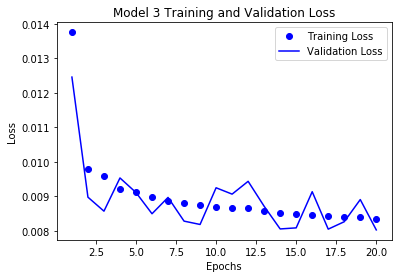

```python
score3, pred_score3 = evaluate_model(model3, model3_hist_dict, test_x_np, test_y_np, pred_test_x_np, pred_test_y_np,
                                     batch_model3, 3)
```

Call the function to generate the predictions for both the testing/validation and prediction/Kaggle data and to save the predictions and truth from the prediction/Kaggle data to output files.

```
Model 3 Test RMSE: 0.702766
Model 3 Test MAE: 0.482000
```

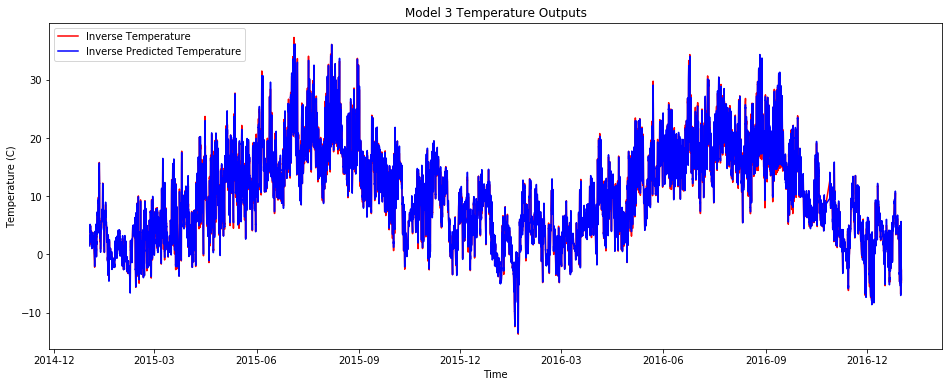

```
Model 3 Kaggle Prediction Test RMSE: 0.702616
Model 3 Kaggle Prediction Test MAE: 0.481935
```

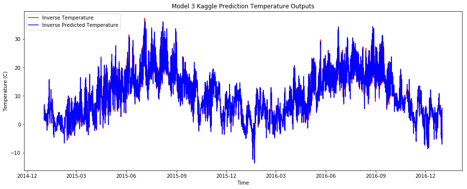

```python
rmse3, mae3, pred_rmse3, pred_mae3 = create_and_save_pred_data(model3, test_x_np, test_norm_df, test_y_np,
                                    pred_test_x_np, pred_test_norm_df, pred_test_y_np, 3)
```

Append the loss data from this model to the lists initialized before the modeling section. Again, this is not required for the final model but is included in the final code since I used this information in deciding the best model.

```python
model_nums.append(3)
scores.append(score3)
pred_scores.append(pred_score3)
rmse_vals.append(rmse3)
pred_rmse_vals.append(pred_rmse3)
mae_vals.append(mae3)
pred_mae_vals.append(pred_mae3)
```

```python
min_loss3, min_val_loss3, last_loss3, last_val_loss3 = get_loss_results(model3_hist_dict)
min_loss_diff3 = abs(min_val_loss3 - min_loss3)
last_loss_diff3 = abs(last_val_loss3 - last_loss3)

min_losses.append(min_loss3)
min_val_losses.append(min_val_loss3)
min_loss_diffs.append(min_loss_diff3)
last_losses.append(last_loss3)
last_val_losses.append(last_val_loss3)
last_loss_diffs.append(last_loss_diff3)
```

# Compile, Plot, and Save Results

The plot below shows the model testing/validation and prediction/Kaggle scores over model number. Again, this is not required for the final model since there is only one data point of each to plot but is included in the final code since I used this information in deciding the best model.

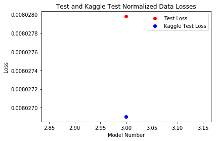

```python
# "bo" is for "blue dot"
plt.plot(model_nums, scores, 'ro', label = 'Test Loss')

# b is for "solid blue line"
plot_title = 'Test and Kaggle Test Normalized Data Losses'
plt.plot(model_nums, pred_scores, 'bo', label = 'Kaggle Test Loss')
plt.title(plot_title)
plt.xlabel('Model Number')
plt.ylabel('Loss')
plt.legend()

plt.show()
```

The plot below shows the testing/validation and prediction/Kaggle inverse transformed MAE values over model number. Again, this is not required for the final model since there is only one data point of each to plot but is included in the final code since I used this information in deciding the best model.

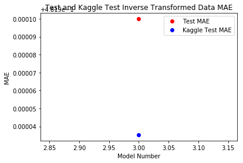

```python
# "bo" is for "blue dot"
plt.plot(model_nums, mae_vals, 'ro', label = 'Test MAE')

# b is for "solid blue line"
plot_title = 'Test and Kaggle Test Inverse Transformed Data MAE'
plt.plot(model_nums, pred_mae_vals, 'bo', label = 'Kaggle Test MAE')
plt.title(plot_title)
plt.xlabel('Model Number')
plt.ylabel('MAE')
plt.legend()

plt.show()
```

Create a dataframe with all of the score, RMSE, and MAE results for all models. Again, this is not required for the final model since there is only one data point of each to plot but is included in the final code since I used this information in deciding the best model.

```python
results_df = pd.DataFrame(model_nums, columns = ['model_nums'])
results_df['scores'] = scores
results_df['pred_scores'] = pred_scores
results_df['rmse_vals'] = rmse_vals
results_df['pred_rmse_vals'] = pred_rmse_vals
results_df['mae_vals'] = mae_vals
results_df['pred_mae_vals'] = pred_mae_vals
```

Find the minimum prediction/Kaggle data MAE value and the model it corresponds to. Again, this is not required for the final model since there is only one data point of each to plot but is included in the final code since I used this information in deciding the best model.

```python
min_vals = results_df.min()
pred_mae_min = min_vals[6]
min_ndxs = results_df.idxmin()
model_min = min_ndxs[6] + 1

print('Minimum MAE: %.6f' % pred_mae_min)
print('Model with Minimum MAE: %d' % model_min)
```

[output not shown]

Save the score, RMSE, and MAE data to an output file for use in offline analysis. Again, this is not required for the final model since there is only one data point of each to plot but is included in the final code since I used this information in deciding the best model.

```python
res_out_file = 'C:\\DePaulCoursework\\Fall 2018 CSC 578\\Assignments\\Final Project\\Outputs\\All_Model_Results.csv'
results_df.to_csv(res_out_file, header  = True, index  = False)
```

Create a dataframe with all of the loss calculations for all models. Again, this is not required for the final model since there is only one data point of each to plot but is included in the final code since I used this information in deciding the best model.

```python
losses_df = pd.DataFrame(model_nums, columns = ['model_nums'])
losses_df['min_losses'] = min_losses
losses_df['min_val_losses'] = min_val_losses
losses_df['min_loss_diffs'] = min_loss_diffs
losses_df['last_losses'] = last_losses
losses_df['last_val_losses'] = last_val_losses
losses_df['last_loss_diffs'] = last_loss_diffs
```

Save the loss calculation data to an output file for use in offline analysis. Again, this is not required for the final model since there is only one data point of each to plot but is included in the final code since I used this information in deciding the best model.

```python
out_file = 'C:\\DePaulCoursework\\Fall 2018 CSC 578\\Assignments\\Final Project\\Outputs\\All_Model_Loss_Data.csv'
losses_df.to_csv(out_file, header = True, index  = False)
```